# Fair Play: Examining Pay Equity and Rise of International MLB Players

Analyzing Trends in Player Performance and Compensation

2024-12-07

## 1. Introduction

Over the past several decades, Major League Baseball (MLB) has witnessed a dramatic increase in the number of international players. As these athletes contribute significantly to the league’s success, questions arise about whether they are compensated equitably compared to their domestic counterparts.

This project explores the intersection of international representation and pay equity in MLB from 1985 to 2016. Using the `Lahman` database and data from Baseball Reference, we can analyze trends in player demographics, salary distributions, and performance metrics. In addition, there will be exploration of the full database, with regards to overall performance metrics and award history to compare the proportion of top international-born players.

This project investigates whether international players are paid fairly relative to their contributions, whether country of origin correlates with top annual performers, and how historical and economic factors shape these outcomes over time.

From a personal perspective, I have been surrounded by baseball from an early age, whether it be a player or fan. My first baseball game was at the old Busch Stadium in St. Louis, in which the St. Louis Cardinals played the Atlanta Braves. I was 2 years old and my dad stuffed my ears with cotton to handle the crowd noise. From then, I was hooked. Always mimicking popular players’ batting stances, keeping journals of baseball statistics, and learning how to score baseball games properly. Once I was able to play in our public leagues, I strived to be the best second baseman and relief pitcher on my team - I’d like to believe I managed this goal, but perhaps a picture might show it best:

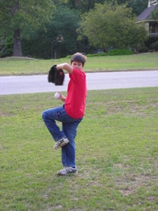

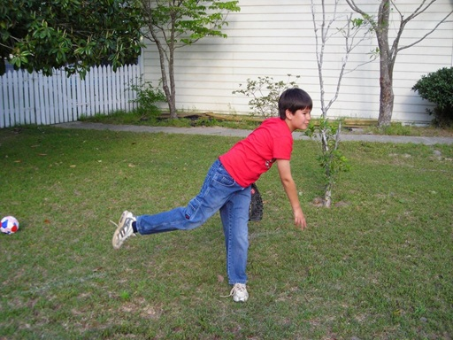

Growing up in Georgia, I’ve always been a fan of the Braves, witnessing countless records and Hall of Fame players during the peak of the late 90s/early 2000’s Braves dynasty. My dad, brother, and I would often attend multiple games a year, mostly at the old Turner Field in Atlanta.

[figure not shown]

Playing baseball as a kid was central to my identity and I’ve remained a baseball fan since, always catching games at PNC Park when the Braves visit (and usually win against) the Pirates.

The findings aim to provide insights into the systemic disparities that may exist in player compensation and highlight opportunities for policy recommendations that foster fairness for international-born players. By examining trends in pay and performance across countries of origin, this analysis contributes to a broader understanding of equity in professional sports and its implications for future policy.

## 2. Outline of Project

Below is the outline of the project, along with relevant research questions that I hope to answer.

#### **Introduction**

- **Focus**: Investigate trends in MLB player demographics, performance, and pay equity.
- **Objectives**:
  - Investigate the rise of international players in MLB.
  - Compare pay equity between international and domestic players.
  - Explore the impact of international status on performance metrics.

#### **Methods**

- **Dataset Loading and Cleaning**:
  - Loaded `Lahman` database, merging WAR data from Baseball Reference.
  - Corrected country names and consolidated them into parent nations.
  - Trimmed down dataset to remove entries with missing values that would be necessary for my analyses

#### **Analysis 1: Demographics and Debut Trends**

- **Research Questions**:
  - How has the proportion of international MLB players changed over time?
  - Do international players debut at younger ages than domestic players?
  - What do their performance metrics look like compared to domestic players?

#### **Analysis 2: Pay Equity**

- **Research Questions**:
  - Is there a significant difference in salary based on WAA for international vs. domestic players?
  - Have these differences changed over time?

#### **Conclusion**

- **Summary**:
  - Highlight findings on demographics, performance metrics, and pay equity.
  - Discuss implications for MLB policies.
- **Call to Action**: Advocate for equitable pay structures and highlight the importance of further research into these trends.

## 3. Lahman Database and Baseball Reference (BR)

This database contains pitching, hitting, and fielding statistics for Major League Baseball from 1871 through 2023. It includes data from the two current leagues (American and National), the four other “major” leagues (American Association, Union Association, Players League, and Federal League), and the National Association of 1871-1875.

This database was created by Sean Lahman, who pioneered the effort to make baseball statistics freely available to the general public. What started as a one man effort in 1994 has grown tremendously, and now a team of researchers have collected their efforts to make this the largest and most accurate source for baseball statistics available anywhere. A preview of the `People` dataset from `Lahman` is provided as an example. Other datasets from `Lahman` that will be used include `Teams`, `AwardsPlayers`, and `Salaries`.

#### Lahman

```r
# loading People dataset as an object for ease of manipulation
players_lahman_only <- People

# preview of the People dataset
head(players_lahman_only)
```

```
##    playerID birthYear birthMonth birthDay  birthCity birthCountry birthState
## 1 aardsda01      1981         12       27     Denver          USA         CO
## 2 aaronha01      1934          2        5     Mobile          USA         AL
## 3 aaronto01      1939          8        5     Mobile          USA         AL
## 4  aasedo01      1954          9        8     Orange          USA         CA
## 5  abadan01      1972          8       25 Palm Beach          USA         FL
## 6  abadfe01      1985         12       17  La Romana         D.R.  La Romana
##   deathYear deathMonth deathDay deathCountry deathState deathCity nameFirst
## 1        NA         NA       NA         <NA>       <NA>      <NA>     David
## 2      2021          1       22          USA         GA   Atlanta      Hank
## 3      1984          8       16          USA         GA   Atlanta    Tommie
## 4        NA         NA       NA         <NA>       <NA>      <NA>       Don
## 5        NA         NA       NA         <NA>       <NA>      <NA>      Andy
## 6        NA         NA       NA         <NA>       <NA>      <NA>  Fernando
##   nameLast        nameGiven weight height bats throws      debut   bbrefID
## 1  Aardsma      David Allan    215     75    R      R 2004-04-06 aardsda01
## 2    Aaron      Henry Louis    180     72    R      R 1954-04-13 aaronha01
## 3    Aaron       Tommie Lee    190     75    R      R 1962-04-10 aaronto01
## 4     Aase   Donald William    190     75    R      R 1977-07-26  aasedo01
## 5     Abad    Fausto Andres    184     73    L      L 2001-09-10  abadan01
## 6     Abad Fernando Antonio    235     74    L      L 2010-07-28  abadfe01
##    finalGame  retroID  deathDate  birthDate
## 1 2015-08-23 aardd001       <NA> 1981-12-27
## 2 1976-10-03 aaroh101 2021-01-22 1934-02-05
## 3 1971-09-26 aarot101 1984-08-16 1939-08-05
## 4 1990-10-03 aased001       <NA> 1954-09-08
## 5 2006-04-13 abada001       <NA> 1972-08-25
## 6 2021-10-01 abadf001       <NA> 1985-12-17
```

Seems we have data that is either incomplete or inaccurate, so we must clean the `birthCountry` data to reflect the proper designations. For the purposes of consistency, territories and constituent countries are merged into their “parent” country, while errors in spelling and/or acronyms are fixed for ease of reading.

There is an argument that cultural identity of many Latin American and Caribbean territories/constituent countries does not match that of the parent nation. However, by combining these values, we are able to look at countries of origin more broadly and accounting for players whose smaller sample size could otherwise suffer from low power. Nevertheless, it is important to be mindful of cultural identity when discussing individual players and the importance of one’s heritage at the MLB level, for which there are many events that highlight these differences.

**Special Case**: Because American Samoa, Puerto Rico, U.S. Virgin Islands, and Guam are territories of the United States, they could be excluded from the international-born player analyses, as they would be merged into the USA category.

I want to do justice to prolific players who come from Puerto Rico and not dilute their contributions under the USA umbrella. Puerto Rico yields a strongly represented proportion of MLB players; therefore, in order to increase power while maintaining cultural sensitivity. Players from American Samoa, Guam and the US Virgin Islands are a much smaller proportion, constituting only 17 players (1 from American Samoa, 14 from V.I. and 2 from Guam), but will still fall under this case for consistency.

```r
players_lahman_only <- players_lahman_only %>%
  mutate(birthCountry = case_when(
    birthCountry == "D.R." ~ "Dominican Republic",
    birthCountry =="Ukriane" ~ "Ukraine",
    birthCountry == "CAN" ~ "Canada",
    birthCountry == "P.R." ~ "Puerto Rico",
    birthCountry== "Viet Nam" ~ "Vietnam",
    birthCountry == "Bohemia" ~ "Czech Republic",
    birthCountry == "England" ~ "United Kingdom",
    birthCountry =="Curacao" ~ "Netherlands",
    birthCountry == "Aruba" ~ "Netherlands",
    birthCountry == "Hong Kong" ~ "China",
    birthCountry == "Taiwan" ~ "China",
    birthCountry == "V.I." ~ "U.S. Virgin Islands",
    TRUE ~ birthCountry))

# determine if there are missing values for birth country
colSums(is.na(players_lahman_only))
```

```
##     playerID    birthYear   birthMonth     birthDay    birthCity birthCountry
##            0          106          275          417          143           55
##   birthState    deathYear   deathMonth     deathDay deathCountry   deathState
##          546        10744        10745        10746        10746        10806
##    deathCity    nameFirst     nameLast    nameGiven       weight       height
##        10748           34            0           37          845          765
##         bats       throws        debut      bbrefID    finalGame      retroID
##         1218         1013          286           54          286           76
##    deathDate    birthDate
##        10746          417
```

Because there is missing data in the `birthCountry` column, it complicates the analysis somewhat. I would have two options in this case:

**1) Individually fix each data point**: By referencing other sources, such as Baseball Reference, I could manually fix each data point; however, with 55 players missing data about their birth country, this would take a long time and runs the risk of data entry error.

**2) Exclude the data points with missing data**: By removing these values, it provides an easy method to move forward; however, when removing data, it is important to determine how many data points would be lost **and** if the removal compromises the analyses. If we make the assumption that all NA values in `birthCountry` are, in fact, international, we can then determine how much data we would be losing.

```r
# create list of players with missing birthCountry data
missing_country <- players_lahman_only %>%
  filter(is.na(birthCountry))

# determine if there are duplicate entries in this list
missing_players <- unique(missing_country$playerID)

# determine if there are playerID's that actually have correct values in other years, but had an NA due to data entry error
missing_players_dupes <- players_lahman_only %>%
  filter(playerID %in% missing_players)
```

Given the missing data only constitutes 55 unique players, assuming that all NA values **could** be international, I felt that a potential loss of 0.262% was reasonably within bounds to exclude from the full dataset.

#### Baseball Reference

Additionally, the `Lahman` database includes an ID number to be linked to publicly available sabermetrics data (conducted by the Society for American Baseball Research, but popularized by the movie “Moneyball”) on the popular baseball database, Baseball Reference (BR). Sabermetrics look beyond classic statistics, to determine player efficiency and performance, using composite values from complex (yet published) equation modeling. As such, I have pulled the Wins Above Average values for all players in the `Lahman` database and merged the corresponding data in my analyses.

Wins Above Average, according to BR, is “a statistical measure that defines a player’s worth in terms of his contribution as compared to the average major league player. WAA is strongly correlated to team performance, that is the sum of WAA by all of a team’s players will almost always represent its final record.”

While `Lahman` is native to R, BR’s database is available as .csv files, which will be merged with `Lahman` to conduct my analyses, re: player performance and relative compenstation. This column will be listed as `WAA` in the merged dataset.

```r
# import batting data from BR
batting_br <- read.csv("batting.csv")

# previews of the batting data from BR
head(batting_br)
```

```
##     name_common age mlb_ID player_ID year_ID team_ID stint_ID lg_ID PA  G  Inn
## 1 David Aardsma  22 430911 aardsda01    2004     SFG        1    NL  0 11 10.7
## 2 David Aardsma  24 430911 aardsda01    2006     CHC        1    NL  3 43 53.0
## 3 David Aardsma  25 430911 aardsda01    2007     CHW        1    AL  0  2 32.3
## 4 David Aardsma  26 430911 aardsda01    2008     BOS        1    AL  1  5 48.7
## 5 David Aardsma  27 430911 aardsda01    2009     SEA        1    AL  0  3 71.3
## 6 David Aardsma  28 430911 aardsda01    2010     SEA        1    AL  0  4 49.7
##   runs_bat runs_br runs_dp runs_field runs_infield runs_outfield runs_catcher
## 1     0.00       0       0          0         0.00          0.00         0.00
## 2    -0.90       0       0          0         0.00          0.00         0.00
## 3     0.00       0       0          0         0.00          0.00         0.00
## 4    -0.29       0       0          0         0.00          0.00         0.00
## 5     0.00       0       0          0         0.00          0.00         0.00
## 6     0.00       0       0          0         0.00          0.00         0.00
##   runs_good_plays runs_defense runs_position runs_position_p runs_replacement
```

[output cut: 41 more lines]

Because the playerIDs on BR differ from those of `Lahman`, we have to link the BR data with a corresponding value. Fortunately, `Lahman` includes a reference ID in the `People` dataset, allowing for easy merging.

**Special Case:** However, with the introduction of the Designated Hitter rule to the American League in 1973, pitchers in the American League do not have Batting WAA beyond 1973; whereas, pitchers batted in the National League until 2020. Therefore, we will only analyze offensive players because there would be separate values for pitchers, while batters would only have one (barring position players who came in to pitch during a blowout and/or a lack of available pitchers due to injury).

You might ask why the values cannot be combined to capture overall contributions to the team; however, because pitchers are notoriously weak batters and batters are notoriously poor pitchers, we do not want an extremely negative value on either end to skew a composite value to reduce their overall contributions (in their main role) to the team.

```r
# renaming ID column in BR to match the merge value in Lahman
names(batting_br)[names(batting_br) == "player_ID"] <- "bbrefID"
names(batting_br)[names(batting_br) == "WAA"] <- "WAA_batting"


# merging datasets together with respect to batting
final_df <- left_join(players_lahman_only, batting_br, by = "bbrefID", "year_id") %>%
  filter(pitcher != "Y")
```

## 4. Analysis 1: Demographics and Trends in Performance of International Players

In this section, we will explore demographics of the MLB, along with trends related to debuts in the MLB and performance metrics. We will also compare these data with domestic players to determine diferences (if any) between the two groups.

#### Demographics

```r
# filtering for list of international-born players
intl_players <- final_df %>%
  filter(birthCountry != "USA") %>%
  select(playerID, nameFirst, nameLast, birthCountry)

summary(unique(intl_players$playerID))
```

```
##    Length     Class      Mode
##      1530 character character
```

```r
# list of countries of origin
countries_of_origin <- intl_players %>%
  distinct(playerID, birthCountry) %>%
  group_by(playerID)

# count the number of countries represented
dist_countries <- table(countries_of_origin$birthCountry)
dist_countries <- as.data.frame(dist_countries)
names(dist_countries) <- c("Country", "Count")
unique(dist_countries$Country)
```

```
##  [1] American Samoa      Australia           Bahamas
##  [4] Belgium             Belize              Brazil
##  [7] Canada              China               Colombia
## [10] Cuba                Czech Republic      Denmark
## [13] Dominican Republic  France              Germany
## [16] Greece              Guam                Honduras
## [19] Ireland             Italy               Jamaica
## [22] Japan               Latvia              Mexico
## [25] Netherlands         Nicaragua           Norway
## [28] Panama              Poland              Portugal
## [31] Puerto Rico         Russia              Saudi Arabia
## [34] Singapore           Slovakia            South Africa
## [37] South Korea         Spain               Sweden
## [40] Switzerland         U.S. Virgin Islands Ukraine
## [43] United Kingdom      Venezuela
## 44 Levels: American Samoa Australia Bahamas Belgium Belize Brazil ... Venezuela
```

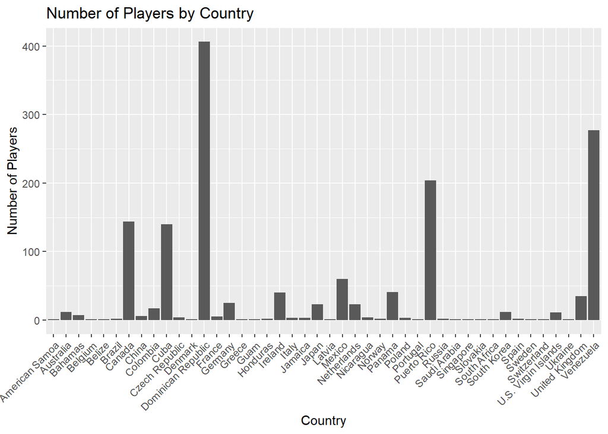

```r
# plot the results of the count
ggplot(dist_countries,
       aes(x = Country,
           y = Count)) +
  geom_bar(stat = "identity") +
  labs(
    title = "Number of Players by Country",
    x = "Country",
    y = "Number of Players") +
  theme(axis.text.x = element_text(angle = 45, hjust = 1))
```

Unfortunately, this is not a very useful graph, largely because there is such a large range in values on the y-axis. We can instead display this information as a table for easier viewing.

```r
dist_countries <- dist_countries %>%
  arrange(desc(Count))

kable(dist_countries,
        caption = "Distribution of Countries Represented by MLB Players")
```

Distribution of Countries Represented by MLB Players

| Country | Count |
| --- | --- |
| Dominican Republic | 406 |
| Venezuela | 277 |
| Puerto Rico | 204 |
| Canada | 144 |
| Cuba | 140 |
| Mexico | 60 |
| Panama | 41 |
| Ireland | 40 |
| United Kingdom | 35 |
| Germany | 25 |
| Japan | 23 |
| Netherlands | 23 |
| Colombia | 17 |
| Australia | 12 |
| South Korea | 12 |
| U.S. Virgin Islands | 11 |
| Bahamas | 7 |
| China | 6 |
| France | 5 |
| Czech Republic | 4 |
| Nicaragua | 4 |
| Italy | 3 |
| Jamaica | 3 |
| Poland | 3 |
| Brazil | 2 |
| Honduras | 2 |
| Norway | 2 |
| Russia | 2 |
| Spain | 2 |
| American Samoa | 1 |
| Belgium | 1 |
| Belize | 1 |
| Denmark | 1 |
| Greece | 1 |
| Guam | 1 |
| Latvia | 1 |
| Portugal | 1 |
| Saudi Arabia | 1 |
| Singapore | 1 |
| Slovakia | 1 |
| South Africa | 1 |
| Sweden | 1 |
| Switzerland | 1 |
| Ukraine | 1 |

If we only focus on the top 10 results, we get a plot with better resolution, as seen below.

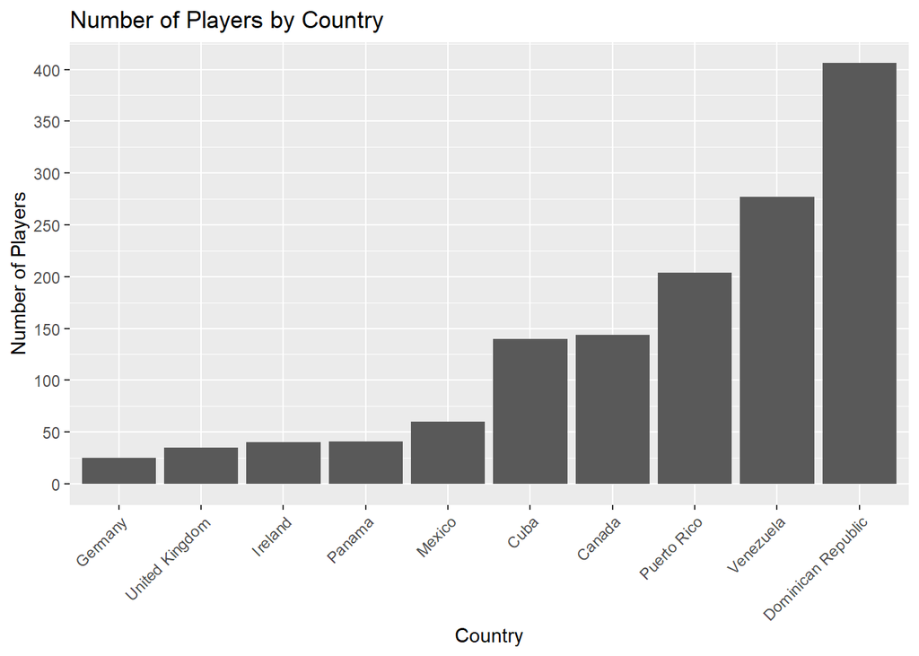

```r
dist_countries_top10 <- dist_countries %>%
  arrange(desc(Count)) %>%
  slice_head(n = 10)

ggplot(dist_countries_top10,
       aes(x = reorder(Country, Count),
           y = Count)) +
  geom_bar(stat = "identity") +
  labs(
    title = "Number of Players by Country",
    x = "Country",
    y = "Number of Players") +
  theme(axis.text.x = element_text(angle = 45, hjust = 1)) +
  scale_y_continuous(
    breaks = seq(0, max(dist_countries_top10$Count), by = 50))
```

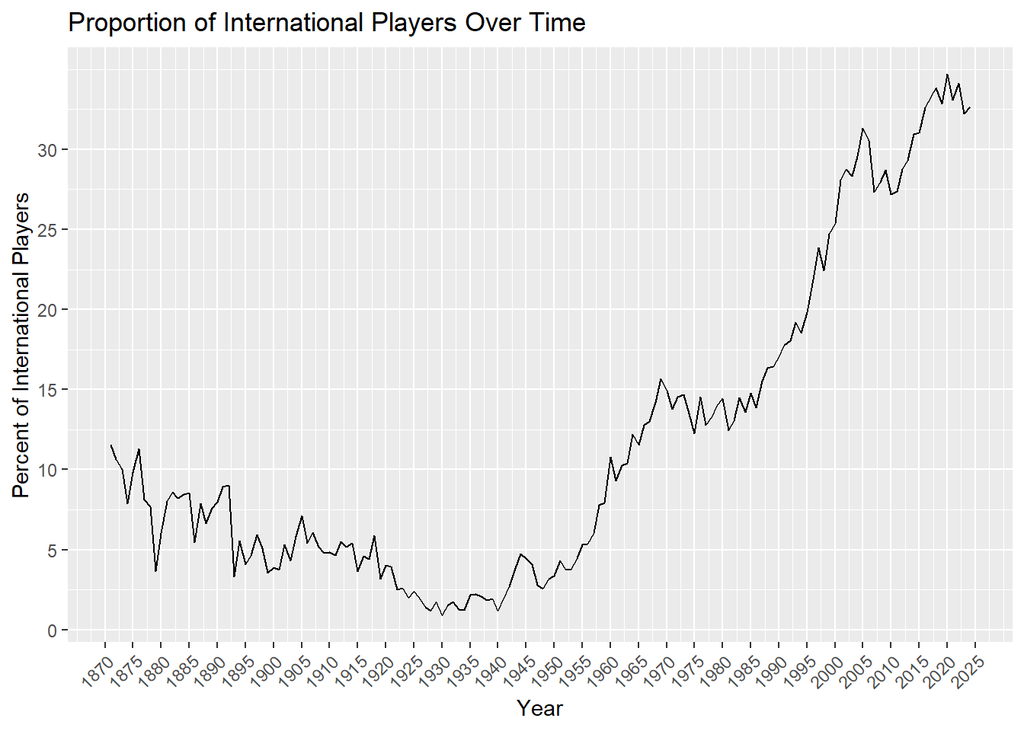

```r
remove_na_year_birth <- final_df[final_df$birthCountry != "USA" & !is.na(final_df$birthCountry) & !is.na(final_df$year_ID), ]

intl_players_per_year <- aggregate(x = remove_na_year_birth$playerID,
                                   by = list(Year = remove_na_year_birth$year_ID),
                                   FUN = length)
colnames(intl_players_per_year)[2] <- "Count"

total_players_per_year <- aggregate(x = final_df$playerID,
                                    by = list(Year = final_df$year_ID),
                                    FUN = length)
colnames(total_players_per_year)[2] <- "Count"

proportion_intl_per_year <- intl_players_per_year %>%
  left_join(total_players_per_year, by = "Year") %>%
  mutate(proportion_intl = (intl_players_per_year$Count / total_players_per_year$Count)*100) %>%
  select(Year, proportion_intl)

colnames(proportion_intl_per_year)[2] <- "Percent"

ggplot(proportion_intl_per_year, aes(x = Year, y = Percent)) +
  geom_line() +
  labs(title = "Proportion of International Players Over Time",
       x = "Year",
       y = "Percent of International Players") +
  scale_x_continuous(breaks = seq(1870, max(proportion_intl_per_year$Year)+2, by = 5)) +
  scale_y_continuous(breaks = seq(0, max(proportion_intl_per_year$Percent), by = 5)) +
  theme(axis.text.x = element_text(angle = 45, hjust = 1))
```

#### Debut Ages

On the domestic side, with the improvement in development teams in college baseball, younger players who are scouted during high school are opting to spend 3-4 years in college to tap into otherwise-inaccessible development for those immediately declaring for the MLB draft. By delaying their recruitment, domestic players are able to develop their skills, increase their market value and draft stock, and gain educational funding.

However, how much do these timelines actually differ beyond anecdotal evidence by MLB pundits?

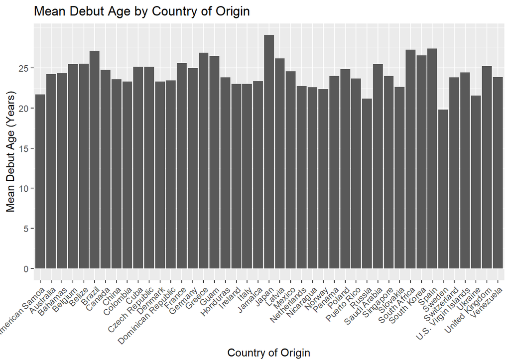

```r
# pulling debut data and player birth date
intl_players_debut <- final_df %>%
  filter(birthCountry != "USA") %>%
  select(playerID, birthCountry, birthDate, debut)

# converting string data into date format and calculate days into years
debut_age_summary <- intl_players_debut %>%
  mutate(debut = as.Date(debut, format = "%Y-%m-%d"),
         birthDate = as.Date(birthDate, format = "%Y-%m-%d")) %>%
  filter(!is.na(birthCountry), !is.na(birthDate), !is.na(debut)) %>%
  mutate(debut_age = as.numeric(difftime(debut, birthDate, units = "days")) / 365.25)

# assign debut age to each unique player ID
debut_age_summary <- aggregate(x = debut_age_summary$debut_age,
                                   by = list(playerID = debut_age_summary$playerID),
                                   FUN = mean)
# rename default "x" to debutAge
colnames(debut_age_summary)[2] <- "debutAge"

# combine birthCountry data
debut_age_summary <- left_join(intl_players_debut, debut_age_summary, by = "playerID")

# select distinct player ID's with age at debut
debut_age_summary_comb <- debut_age_summary %>%
  select(playerID, birthCountry, debutAge) %>%
  distinct() %>%
  group_by(birthCountry)

# create mean age of debut by country
mean_debut_age_by_country <- aggregate(
  debutAge ~ birthCountry,
  data = debut_age_summary_comb,
  FUN = mean,
  na.rm = TRUE
)

# rename default "data" into avg_debutAge
colnames(mean_debut_age_by_country)[2] <- "avg_debutAge"

# plotting mean debut age by country of origin
ggplot(mean_debut_age_by_country, aes(x = birthCountry, y = avg_debutAge)) +
  geom_bar(stat = "identity") +
  labs(
    title = "Mean Debut Age by Country of Origin",
    x = "Country of Origin",
    y = "Mean Debut Age (Years)"
  ) +
  theme(axis.text.x = element_text(angle = 45, hjust = 1)) +
  scale_y_continuous(breaks = seq(0, max(mean_debut_age_by_country$avg_debutAge), by = 5))
```

Again, this plot isn’t very useful because it does not illustrate the granularity of the differences between each country. This data could be better displayed as a subset of data and table once again. Additionally, displaying the number of players per country could help contextualize the plot.

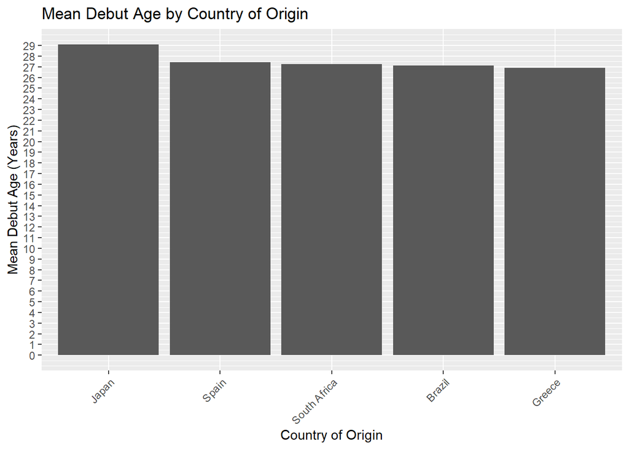

```r
# select top 5 countries by average age of debut
top5_mean_debut_age_by_country <- mean_debut_age_by_country %>%
  arrange(desc(avg_debutAge)) %>%
  slice_head(n = 5)

# plot top 5 countries by average age of debut
ggplot(top5_mean_debut_age_by_country, aes(x = reorder(birthCountry, -avg_debutAge), y = avg_debutAge)) +
  geom_bar(stat = "identity") +
  labs(
    title = "Mean Debut Age by Country of Origin",
    x = "Country of Origin",
    y = "Mean Debut Age (Years)"
  ) +
  theme(axis.text.x = element_text(angle = 45, hjust = 1)) +
  scale_y_continuous(breaks = seq(0, max(mean_debut_age_by_country$avg_debutAge), by = 1))
```

```r
# sorting from greatest age at debut to lowest
mean_debut_age_by_country <- mean_debut_age_by_country %>%
  arrange(desc(avg_debutAge))

# rename columns for better clarity
colnames(mean_debut_age_by_country)[2] <- "avg_debutAge"
colnames(mean_debut_age_by_country)[1] <- "Country"

# Average of all international-born players
round(mean(mean_debut_age_by_country$avg_debutAge),2)
```

```
## [1] 24.36
```

```r
# table representation
kable(mean_debut_age_by_country,
        caption = "Average age of international MLB players at debut")
```

Average age of international MLB players at debut

| Country | avg_debutAge |
| --- | --- |
| Japan | 29.09062 |
| Spain | 27.41410 |
| South Africa | 27.26899 |
| Brazil | 27.13210 |
| Greece | 26.88843 |
| South Korea | 26.58362 |
| Guam | 26.47502 |
| Latvia | 26.17933 |
| France | 25.62355 |
| Belize | 25.54141 |
| Belgium | 25.47570 |
| Saudi Arabia | 25.46475 |
| United Kingdom | 25.25435 |
| Cuba | 25.14263 |
| Czech Republic | 25.12731 |
| Germany | 25.02133 |
| Poland | 24.83687 |
| Canada | 24.77699 |
| Mexico | 24.59462 |
| U.S. Virgin Islands | 24.45150 |
| Bahamas | 24.35866 |
| Australia | 24.24367 |
| Singapore | 24.01917 |
| Panama | 23.99399 |
| Venezuela | 23.87734 |
| Honduras | 23.83710 |
| Switzerland | 23.81109 |
| Puerto Rico | 23.67089 |
| China | 23.57883 |
| Dominican Republic | 23.46137 |
| Jamaica | 23.35387 |
| Colombia | 23.30442 |
| Denmark | 23.28816 |
| Italy | 23.01346 |
| Ireland | 22.99772 |
| Netherlands | 22.74011 |
| Slovakia | 22.63381 |
| Nicaragua | 22.60027 |
| Norway | 22.33676 |
| American Samoa | 21.67009 |
| Ukraine | 21.55510 |
| Russia | 21.16359 |
| Sweden | 19.82204 |

Now that we have the average age of debut for each country and the overall average for international players, we can compare with domestic player debuts.

```r
# creating dataset of all USA-born players
us_players_debut <- final_df %>%
  filter(birthCountry == "USA") %>%
  select(playerID, birthCountry, birthDate, debut)

# cleaning the subset of the data to ensure proper calculation of age of debut
us_players_summary <- us_players_debut %>%
  mutate(debut = as.Date(debut, format = "%Y-%m-%d"),
         birthDate = as.Date(birthDate, format = "%Y-%m-%d")) %>%
  filter(!is.na(birthCountry), !is.na(birthDate), !is.na(debut)) %>%
  mutate(debut_age = as.numeric(difftime(debut, birthDate, units = "days")) / 365.25)

us_debut_age_summary <- aggregate(x = us_players_summary$debut_age,
                                   by = list(playerID = us_players_summary$playerID),
                                   FUN = mean)
# rename "x" to more representative column name
colnames(us_debut_age_summary)[2] <- "debutAge"

# calculation of USA debut ages
round(mean(us_debut_age_summary$debutAge),2)
```

```
## [1] 24.31
```

**Average age of international-born players at debut:** 24.36